# EPL historical data

Hey, guys!

Here’s my EDA on the PL fixtures. From them I also derived the seasonal standings. Have a look below and see what I found.

# How long they have been in the EPL?

[figure not shown]

# Top teams’ W/D/L balance

Please note that the 1993-94 and 1994-95 seasons saw 22 playing in the PL.

[figure not shown]

# Comebacks: What a drama!?!

Look at that! That’s the number of comebacks per season. Unless you are on the wrong side of the scoreboard, it’s always fun to watch these games. Here’s theit distribution in time.

Note: No HT-FT data is available for 1993-94 and 1994-95 season

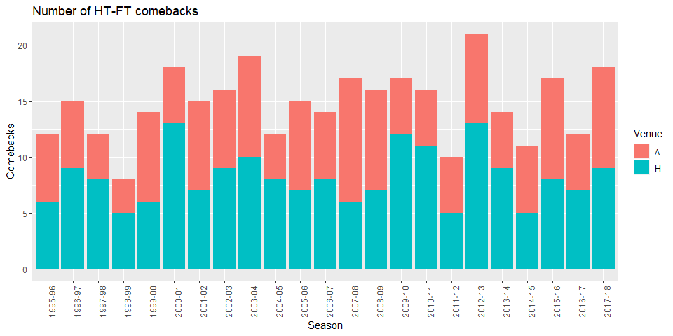

# Streaks

The y-axis on the figures below represents the goal difference, thus they highlight not only the length of a streak but also confidence of the attacking (winning/undefeated streak) or defending players(winless streak).

Please use the tabs to explore all longest streaks regarding the outcome.

## Winning

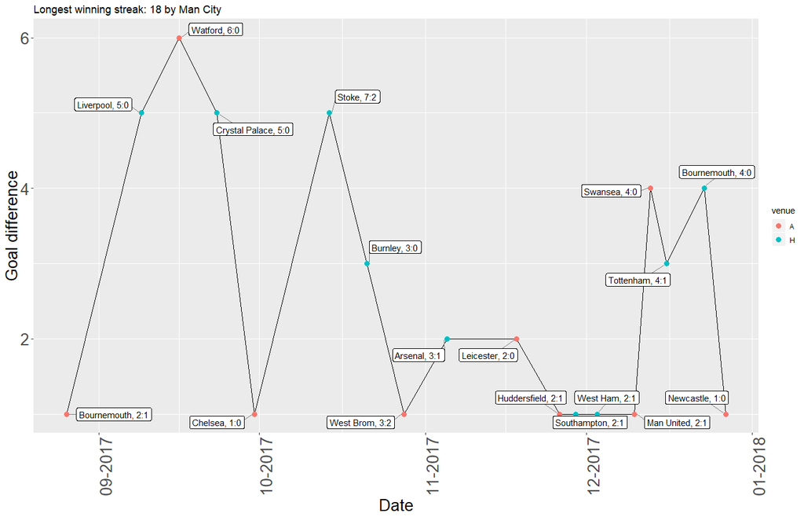

## Winless

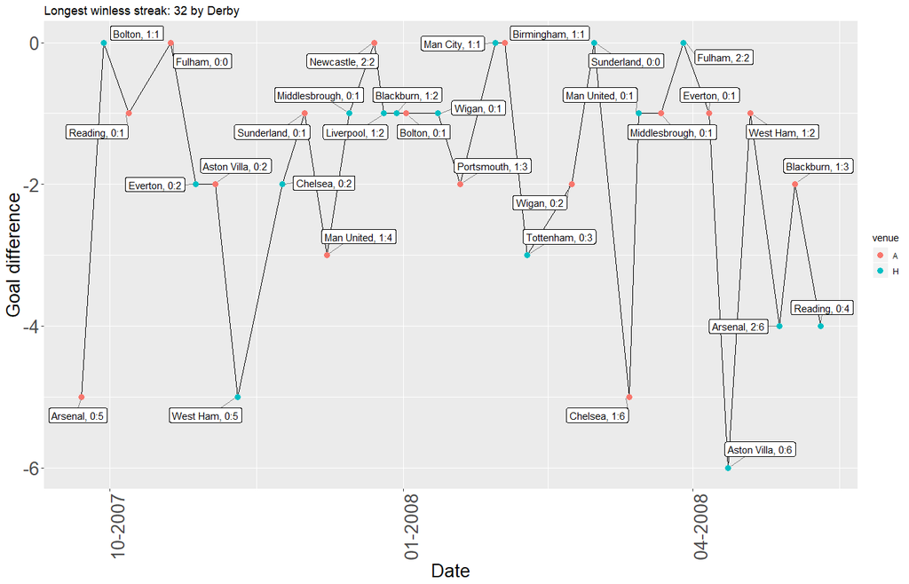

## Undefeated

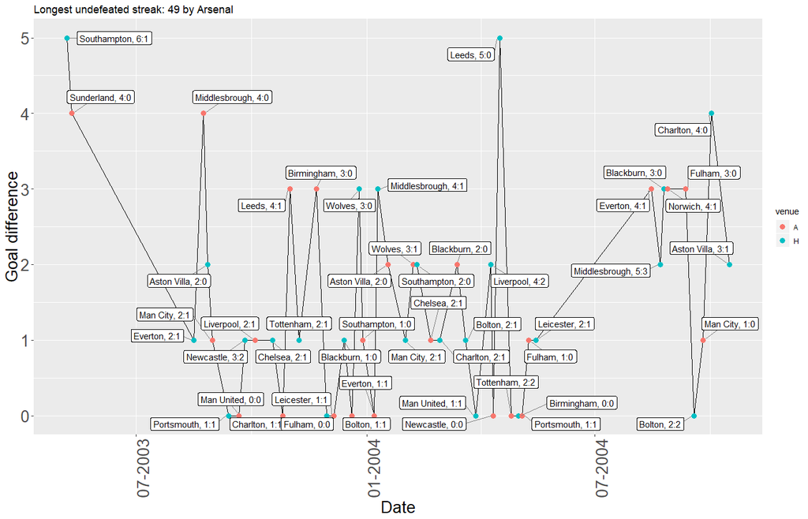

# Standings

## Number of titles

I feel like I owe it to the Man Utd and Chelsea fans and I’ve included the number of titles won by any team in the Premier League era.

[interactive chart not shown]

## Point difference between champion and runner-up

We also have diffrence in points between the champion and the runner-up. Labels are also added to signify the actual winner and second-placed teams.

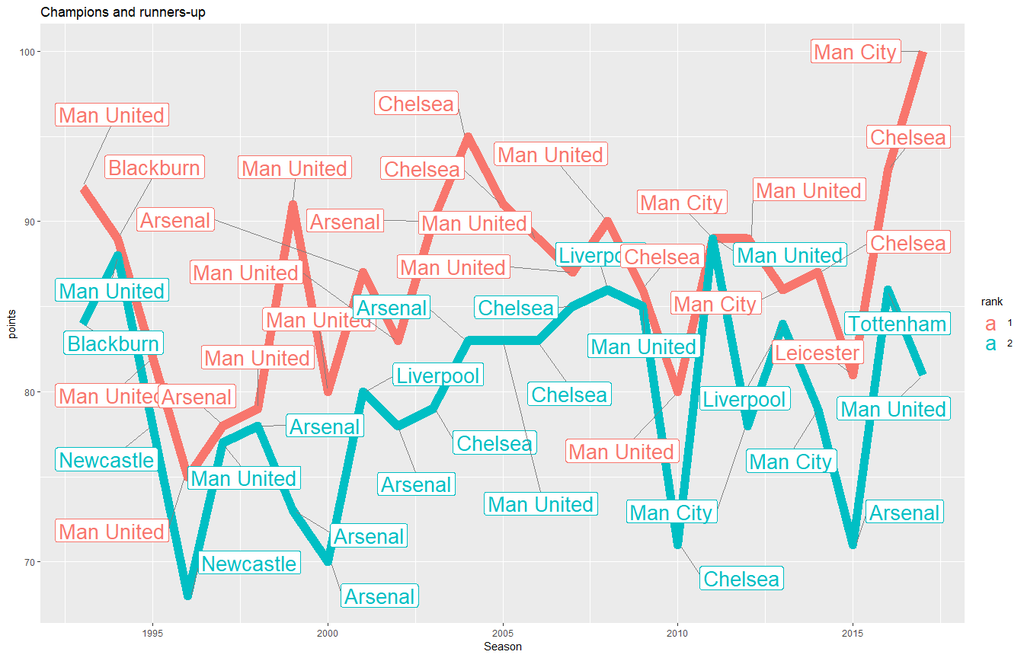

# Regression curves between ranking and other variables

Next on we explore the relationship of team’s ranking with other variables.

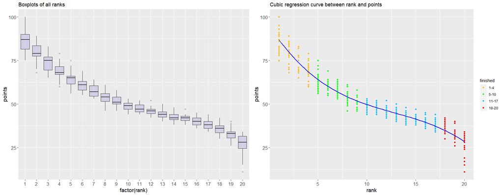

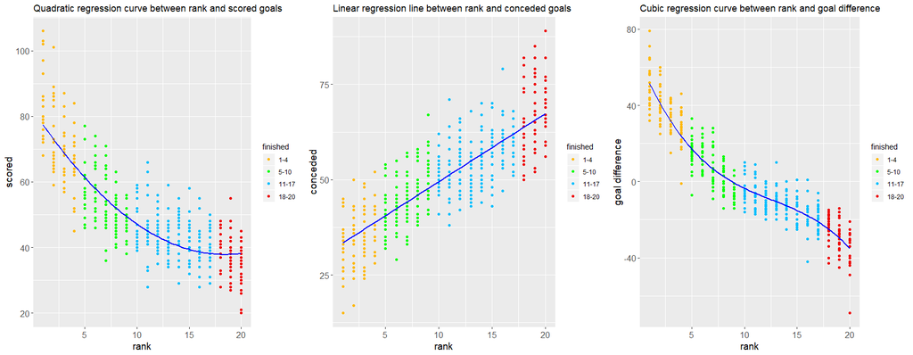

# Prediction of points and goal difference based on ranking

Last, but not least we have prediction of points and goal difference based on season ranking of a team. The dashed lines are just for visual guidance.

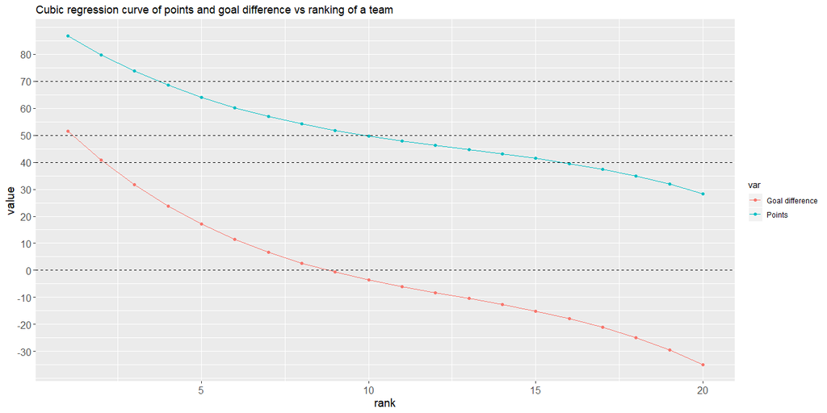